# Wattpad Sentiment Analysis Tutorial

This is an R Markdown document for sentiment analysis of the Wattpad corpus.  
First, let’s upload the corpus.

## Upload Wattpad corpus and call libraries

Each entry in the corpus is composed by 10 parts:  
- unique identifier for book, chapter, and paragraph  
- title of book, chapter, and paragraph  
- name of the user and date of his/her comment  
- the comment  
- a logical TRUE/FALSE, that indicates if the comment is a reply to a previuos comment  
Note that the corpus is a “sample” generated on the basis of the “Pride and Prejudice” dataset.  
The text is the same as it appears in Wattpad and Project Gutenberg; usernames have been anonymized; dates and replies indicators have been scrambled; comments have been generated artifically by re-mixing the words of the actual comments.

```r
wattpad_df <- read.csv("Sample_wattpad_corpus.csv", stringsAsFactors = F)
summary(wattpad_df)
```

```
##      bookID    chapterID      paragraphID        book
##  Min.   :1   Min.   : 1.00   Min.   : 1.00   Length:36491
##  1st Qu.:1   1st Qu.: 2.00   1st Qu.: 6.00   Class :character
##  Median :1   Median :10.00   Median :15.00   Mode  :character
##  Mean   :1   Mean   :18.92   Mean   :18.56
##  3rd Qu.:1   3rd Qu.:34.00   3rd Qu.:27.00
##  Max.   :1   Max.   :61.00   Max.   :77.00
##    chapter           paragraph           username
##  Length:36491       Length:36491       Length:36491
##  Class :character   Class :character   Class :character
##  Mode  :character   Mode  :character   Mode  :character
##
##
##
##      date             comment            reply
##  Length:36491       Length:36491       Mode :logical
##  Class :character   Class :character   FALSE:25851
##  Mode  :character   Mode  :character   TRUE :10640
##
##
##
```

```r
# a library for sentiment analysis
if (!require("syuzhet")) install.packages("syuzhet")
# two libraries for data preparation and visualization
if (!require("tidyverse")) install.packages("tidyverse")
if (!require("reshape2")) install.packages("reshape2")
# a library for the progress bar
if (!require("svMisc")) install.packages("svMisc")
```

## Sentiment analysis on one paragraph

### Step 1

Let’s start by analyzing the first paragraph of the first book  
Isolate book no. 1  
and define a unique identifier for each paragraph

```r
wattpad_df_book <- wattpad_df[which(wattpad_df$bookID == 1),]
allParagraphsID <- paste(wattpad_df_book$bookID, wattpad_df_book$chapterID, wattpad_df_book$paragraphID, sep = "_")
wattpad_df_book <- cbind(wattpad_df_book, allParagraphsID)
paragraph_selection <- unique(allParagraphsID)

cat("Analysis on:",
    wattpad_df_book$book[1], "",
    "Total available paragraphs:",
    length(paragraph_selection), "",
    head(paragraph_selection),
    "...etc.",
    sep = "\n")
```

```
## Analysis on:
## Pride and Prejudice (1813)
##
## Total available paragraphs:
## 2057
##
## 1_1_1
## 1_1_2
## 1_1_3
## 1_1_4
## 1_1_5
## 1_1_6
## ...etc.
```

### Step 2

Let’s focus on paragraph 1_1_1

```r
paragraph <- "1_1_1"
paragraph_for_SA <- wattpad_df_book$paragraph[which(wattpad_df_book$allParagraphsID==paragraph)][1]
comments_for_SA <- wattpad_df_book$comment[which(wattpad_df_book$allParagraphsID==paragraph)]
cat("Here is the paragraph to analyze:\n",
    paragraph_for_SA,
    "\nHere are the comments:\n",
    head(comments_for_SA),
    "...etc.", sep = "\n")
```

```
## Here is the paragraph to analyze:
##
## It is a truth universally acknowledged, that a single man in possession of a good fortune, must be in want of a wife.
##
## Here are the comments:
##
## realized happens bourgh lols oppressive can read impressed m from for scene wanting hahahaha bennet to won s the scene read do dude trying i so his dp again cringes
## uber like married threat get a sass off long feel youuu of actually know u some my about telling class right mr truth were crazy same oh aweee didn d
## husband piano just good and when bae same unlike together with how it language here t nor nibiscuite better are were not i t you rude youtubers hessa bennet drink
## mother he several mr years many happening and your it darcy because i to and mr i the but be is british and way they need weird after lmao she
## even mr from a coz was in first but that way oh world come was elizabeth exactly yass last and but definition triple it mr needs you si person soo
## ughhhhh in this shade but right well cried af frowning been hot financial hahahaha books library but choice lol much one old when cuze it her smh sexist might about
## ...etc.
```

### Step 3

Let’s get the sentiment values for paragraph and comments

```r
paragraph_sentiment <- get_sentiment(paragraph_for_SA, method = "syuzhet")
comments_sentiment <- numeric()
for(comment in head(comments_for_SA)){
  comments_sentiment <- c(comments_sentiment, get_sentiment(comment, method = "syuzhet"))
}
cat("Sentiment of the paragraph:",
    paragraph_sentiment, "",
    "Sentiment of the comments:",
    comments_sentiment,
    "...etc.", "",
    "Total comments to analyze:",
    length(comments_for_SA),
    sep = "\n")
```

```
## Sentiment of the paragraph:
## 2.25
##
## Sentiment of the comments:
## -0.75
## 0.8
## 1.05
## -0.25
## 0
## -0.4
## ...etc.
##
## Total comments to analyze:
## 2512
```

### Step 4

Now, the problem is that we have:  
- one sentiment value for the paragraph  
- multiple sentiment values for the related comments  
To have a single sentiment value for both, a mean is calculated for the comments:

```r
paragraph_sentiment <- get_sentiment(paragraph_for_SA, method = "syuzhet")
comments_sentiment <- 0
for(comment in comments_for_SA){
  comments_sentiment_tmp <- get_sentiment(comment, method = "syuzhet")
  comments_sentiment <- comments_sentiment + comments_sentiment_tmp
}
# normalize per number of comments
comments_sentiment <- comments_sentiment/length(comments_for_SA)

cat("Sentiment of the paragraph:",
    paragraph_sentiment,
    "Mean sentiment of the comments:",
    comments_sentiment,
    sep = "\n")
```

```
## Sentiment of the paragraph:
## 2.25
## Mean sentiment of the comments:
## 0.643133
```

## Sentiment analysis on all paragraphs

### Step 1

Now everything is ready for expanding the analysis to all the paragraphs!  
The below code brings together all the functions defined before into a single function, that iterates on all the paragraphs  
The results are saved in a datafame format

```r
calculate_wattpad_sentiment <- function(book){
  cat("Processing book no.", book, "\n")
  wattpad_df_book <- wattpad_df[which(wattpad_df$bookID == book),]
  allParagraphsID <- paste(wattpad_df_book$bookID, wattpad_df_book$chapterID, wattpad_df_book$paragraphID, sep = "_")
  wattpad_df_book <- cbind(wattpad_df_book, allParagraphsID)
  ###after having prepared the dataframe for the single book, all the possible paragraphs to process are extracted
  paragraph_selection <- unique(allParagraphsID)
  ###all values are initialized (paragraph number, total length of book, and a dataframe where to store results)
  paragraph_number <- 0
  total_length <- 0
  final_results_SA <- data.frame(paragraph = numeric(), paragraph_length = numeric(), paragraph_sentiment = numeric(), comments_sentiment = numeric())
  ###now start iteration on all paragraphs
  # initialize progress bar
  pb = txtProgressBar(max = length(paragraph_selection), style = 3)
  for(paragraph in paragraph_selection){
    # get paragraph and comments
    paragraph_for_SA <- wattpad_df_book$paragraph[which(wattpad_df_book$allParagraphsID==paragraph)][1]
    comments_for_SA <- wattpad_df_book$comment[which(wattpad_df_book$allParagraphsID==paragraph)]
    # get paragraph length
    paragraph_length <- unlist(strsplit(paragraph_for_SA, "\\W"))
    paragraph_length <- paragraph_length[paragraph_length != ""]
    paragraph_length <- length(paragraph_length)
    # increase total length
    total_length <- total_length+paragraph_length
    # get paragraph sentiment
    paragraph_sentiment <- get_sentiment(paragraph_for_SA, method = "syuzhet")
    # get comments sentiment
    comments_sentiment <- 0
    for(comment in comments_for_SA){
      comments_sentiment_tmp <- get_sentiment(comment, method = "syuzhet")
      comments_sentiment <- comments_sentiment + comments_sentiment_tmp
    }
    # normalize per number of comments
    comments_sentiment <- comments_sentiment/length(comments_for_SA)
    # increase paragraph number
    paragraph_number <- paragraph_number+1
    # save results into dataframe
    final_results_SA <- rbind(final_results_SA, data.frame(paragraph_number, paragraph_length, total_length, paragraph_sentiment, comments_sentiment))
    # print progress
    setTxtProgressBar(pb,paragraph_number)
  }
  final_results_SA$percentage_of_book <- final_results_SA$total_length/total_length*100
  cat("\nProcess complete for:", wattpad_df_book$book[1], "\n")
  return(final_results_SA)
}
```

### Step 2

This function can be used to run sentiment analysis on our books selection  
Let’s use it on the first book (Pride and Prejudice)  
[the procedure will take a bit of time]

```r
results_SA <- calculate_wattpad_sentiment(1)
```

```
## Processing book no. 1
##
## Process complete for: Pride and Prejudice (1813)
```

### Step 3

Now the results are stored in the “results_SA” variable  
We can already print them, but (as already shown by Jockers) they are still too noisy to be interpreted

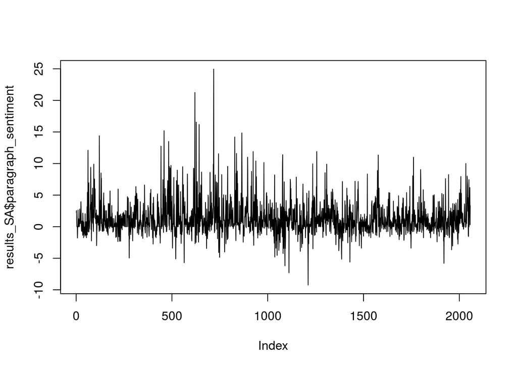

```r
plot(results_SA$paragraph_sentiment, type = "l")
```

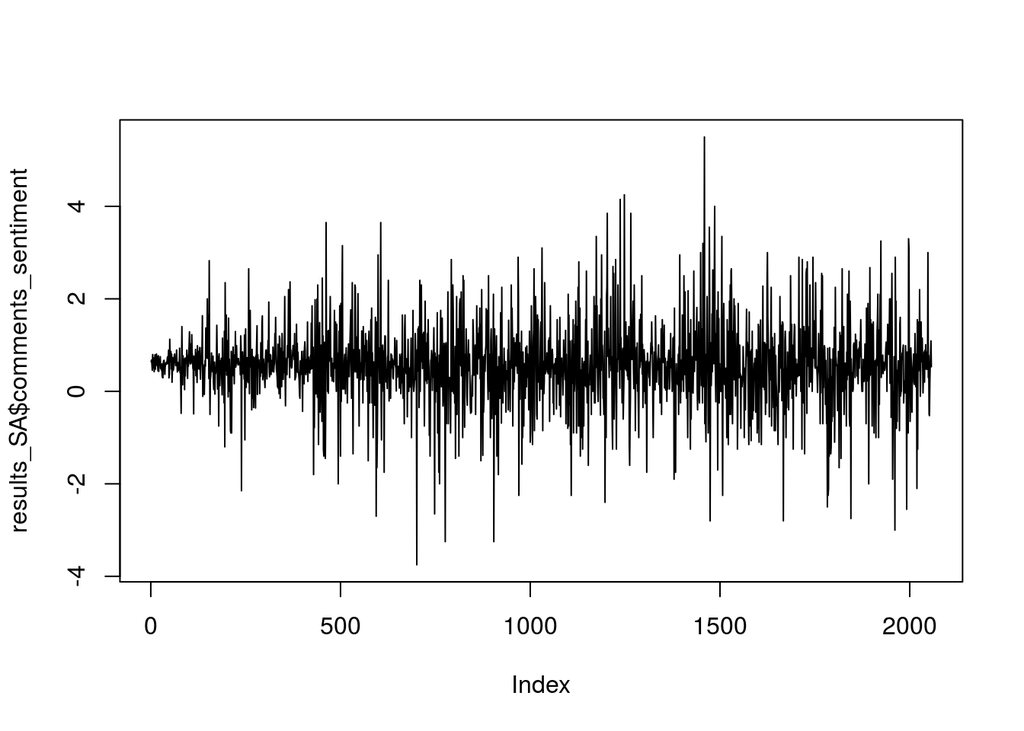

```r
plot(results_SA$comments_sentiment, type = "l")
```

### Step 4

We have to use the moving window procedure, and apply it to the calculated scores  
First we define the functions, then we apply them on the “results_SA” variable

```r
###function for rolling plot (taken from https://github.com/mjockers/syuzhet/blob/master/R/syuzhet.R)
rolling_plot <- function (raw_values, window = 0.1){
  wdw <- round(length(raw_values) * window)
  rolled <- rescale(zoo::rollmean(raw_values, k = wdw, fill = 0))
  half <- round(wdw/2)
  rolled[1:half] <- NA
  end <- length(rolled) - half
  rolled[end:length(rolled)] <- NA
  return(rolled)
}

rolled_wattpad_plots <- function(final_results_SA){
  print("Get rid of NAs")
  final_results_SA$comments_sentiment[which(is.na(final_results_SA$comments_sentiment))] <- 0
  final_results_SA$paragraph_sentiment[which(is.na(final_results_SA$paragraph_sentiment))] <- 0

  print("Calculate rolling mean (as Jockers does...)")
  rolled_plot_paragraphs <- rolling_plot(final_results_SA$paragraph_sentiment, window = 0.1)
  rolled_plot_comments <- rolling_plot(final_results_SA$comments_sentiment, window = 0.1)

  print("Save all to dataframe")
  compare_SA_df <- data.frame(percentage_of_book = final_results_SA$percentage_of_book, paragraph = rolled_plot_paragraphs, comments = rolled_plot_comments)

  return(compare_SA_df)
}

compare_SA_df <- rolled_wattpad_plots(results_SA)
```

```
## [1] "Get rid of NAs"
## [1] "Calculate rolling mean (as Jockers does...)"
## [1] "Save all to dataframe"
```

### Step 5

Now everything is ready to print our plot for the entire book

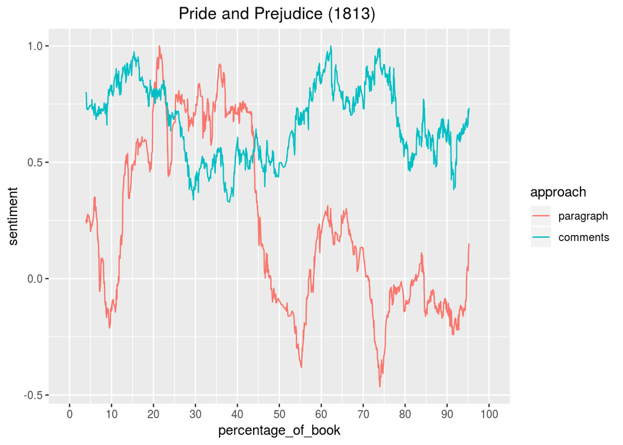

```r
##melt dataframe (to make ggplot graph)
compare_SA_df_melt <- melt(compare_SA_df, id.vars = colnames(compare_SA_df)[1])
colnames(compare_SA_df_melt) <- c("percentage_of_book", "approach", "sentiment")
book_title <- wattpad_df_book$book[1]

p1 <- ggplot(data = compare_SA_df_melt) +
  geom_line(mapping = aes(percentage_of_book, sentiment, color = approach, group = approach)) +
  ggtitle(book_title) +
  theme(plot.title = element_text(hjust = 0.5)) +
  scale_x_continuous(minor_breaks = seq(0,100,5), breaks = seq(0,100,10))
p1
```

### Step 6

In addition, some statistics can be run to verify the connection between text and comments: correlation and linear regression

```r
##correlation
print(cor.test(compare_SA_df$paragraph, compare_SA_df$comments))
```

```
##
##  Pearson's product-moment correlation
##
## data:  compare_SA_df$paragraph and compare_SA_df$comments
## t = -9.4622, df = 1848, p-value < 2.2e-16
## alternative hypothesis: true correlation is not equal to 0
## 95 percent confidence interval:
##  -0.2580101 -0.1710663
## sample estimates:
##        cor
## -0.2149641
```

```r
##regression
model <- lm(compare_SA_df$comments ~ compare_SA_df$paragraph)
print(summary(model))
```

```
##
## Call:
## lm(formula = compare_SA_df$comments ~ compare_SA_df$paragraph)
##
## Residuals:
##      Min       1Q   Median       3Q      Max
## -0.33835 -0.12248  0.01101  0.12785  0.32408
##
## Coefficients:
##                          Estimate Std. Error t value Pr(>|t|)
## (Intercept)              0.700185   0.004069 172.093   <2e-16 ***
## compare_SA_df$paragraph -0.094674   0.010006  -9.462   <2e-16 ***
## ---
## Signif. codes:  0 '***' 0.001 '**' 0.01 '*' 0.05 '.' 0.1 ' ' 1
##
## Residual standard error: 0.1539 on 1848 degrees of freedom
##   (207 observations deleted due to missingness)
## Multiple R-squared:  0.04621,    Adjusted R-squared:  0.04569
## F-statistic: 89.53 on 1 and 1848 DF,  p-value: < 2.2e-16
```